# Digital Signal and Image Management

## Assignment #2

Implementare la funzione di sharpening per esaltare i dettagli di un'immagine in scala di grigi tramite unsharp mask, partendo dalle istruzioni viste ad esercitazione. Verificare l'effetto di diversi parametri coinvolti nelle operazioni utilizzate.

### Packages

```python
import numpy as np

# Gestione immagini
from skimage import io # Per input/output
from skimage import transform # Per trasformazioni geometriche (es. resize)
from skimage import filters # Per filtri locali
from skimage import color # Per cambi colore

# Visualizzazione e interazione
import matplotlib.pyplot as plt
import seaborn as sns
import ipywidgets as widgets

%matplotlib inline
```

Iniziamo innanzitutto importando i pacchetti necessari e la nostra immagine di riferimento

```python
lena = io.imread('imgs/lena.jpg', as_gray = True)
```

[figure not shown]

```python
plt.figure(figsize = (10,10))
plt.imshow(lena, cmap = 'gray')
```

Lo sharpening di un immagine consiste essenzialmente in 3 operazioni:

- Operazione di blurring dell'immagine, ovvero diminuire i dettagli;
- Una volta ricavata un'immagine privata dei dettagli provvedere a sottrarla all'immagine originale così da isolare i dettagli dell'immagine stessa;
- Una volta isolati i dettagli dell'immagine sommarli all'immagine iniziale così da "aumentarli".

In quest'ottica applichiamo un filtro gaussiano alla nostra immagine così da ricavare l'immagine privata dei dettagli, poi produciamo come detto la differenza ed infine sommiamo i dettagli isolati all'immagine originale.

```python
gaus = filters.gaussian(lena, sigma = 50, preserve_range = True)
diff = lena - gaus
rec = lena + diff
rec = np.where(rec < 0, 0, rec)
rec = np.where(rec > 1, 1, rec)
```

A questo punto possiamo verificare le misure della nostra immagine originale e di quella *enhanced* con riferimento anche ai prodotti intermedi.

```python
print(lena.shape, np.max(lena), np.min(lena))
print(gaus.shape, np.max(gaus), np.min(gaus))
print(diff.shape, np.max(diff), np.min(diff))
print(rec.shape, np.max(rec), np.min(rec))
```

```
(400, 400) 0.8989145098039216 0.019776862745098038
(400, 400) 0.5122065020519065 0.21432970125388415
(400, 400) 0.6016428574273418 -0.40407574571043614
(400, 400) 1.0 0.0
```

Plottiamo la distribuzione dei valori dei nostri pixel in modo da verificare quali elementi dell'immagine vengono "aumentati"

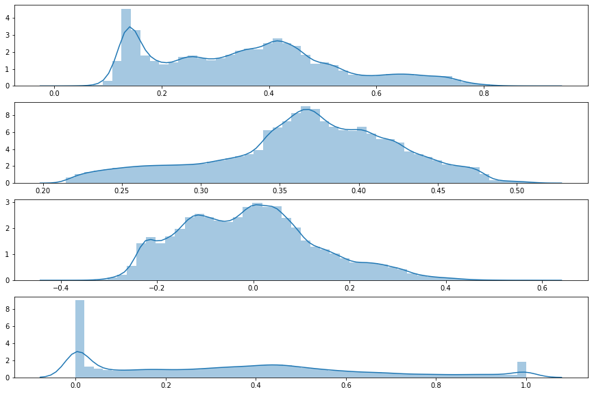

```python
f, axes = plt.subplots(4, 1, figsize = (15,10))
sns.distplot(lena.reshape((lena.shape[0]*lena.shape[1])), hist = True, ax = axes[0])
sns.distplot(gaus.reshape((lena.shape[0]*lena.shape[1])), hist = True, ax = axes[1])
sns.distplot(diff.reshape((lena.shape[0]*lena.shape[1])), hist = True, ax = axes[2])
sns.distplot(rec.reshape((lena.shape[0]*lena.shape[1])), hist = True, ax = axes[3])
```

Come si può vedere dalle distribuzioni la parte degli "scuri" dell'immagine riceve un improvement considerevole, non resta altro che plottare le immagini ed i loro prodotti intermedi per verificare l'impatto dello *sharpening* sull'immagine originale.

[figure not shown]

```python
f, axes = plt.subplots(2,2, figsize = (15,15))
f.suptitle("Image enhancement")
axes[0][0].imshow(lena, cmap = 'gray')
axes[0][0].set_title('Original')
axes[0][1].imshow(gaus, cmap = 'gray')
axes[0][1].set_title("Gaus")
axes[1][0].imshow(diff, cmap = 'gray')
axes[1][0].set_title("Difference")
axes[1][1].imshow(rec, cmap = 'gray')
axes[1][1].set_title("Enhanced")
```

Come si può vedere in questo caso gli scuri sono stati esasperati rispetto all'immagine originale, ciò è osservabile sia dalle immagini che dai plot rappresentanti la distribuzione dei valori dei pixel nelle diverse fasi di elaborazione dell'immagine. E' evidente dall'immagine qui sopra come la procedura non stia funzionando come dovrebbe: per poter infatti mettere in risalto i dettagli il risultato dell'operazione di differenza tra l'immagine originale e quella a cui è stato applicato il filtro gaussiano dovrebbe contenere solo i dettagli dell'immagine così che, una volta sommata all'originale, questi possano effettivamente essere messi in risalto.  
Testiamo un altro valore per il valore **sigma** del filtro gaussiano applicato così da verificarne l'impatto sulla nostra immagine di riferimento. Come è possibile infatti leggere nella documentazione della funzione il parametro **sigma** fa riferimento alla **standard deviation** del filtro gaussiano applicato.

```python
gaus = filters.gaussian(lena, sigma = 20, preserve_range = True)
diff = lena - gaus
rec = lena + diff
rec = np.where(rec < 0, 0, rec)
rec = np.where(rec > 1, 1, rec)
```

```python
print(lena.shape, np.max(lena), np.min(lena))
print(gaus.shape, np.max(gaus), np.min(gaus))
print(diff.shape, np.max(diff), np.min(diff))
print(rec.shape, np.max(rec), np.min(rec))
```

```
(400, 400) 0.8989145098039216 0.019776862745098038
(400, 400) 0.6681342473845875 0.15430978776054535
(400, 400) 0.6311608051502149 -0.4273894612678644
(400, 400) 1.0 0.0
```

Effettuiamo ancora una volta un check della distribuzione dei pixel nelle diverse fasi di elaborazione dell'immagine:

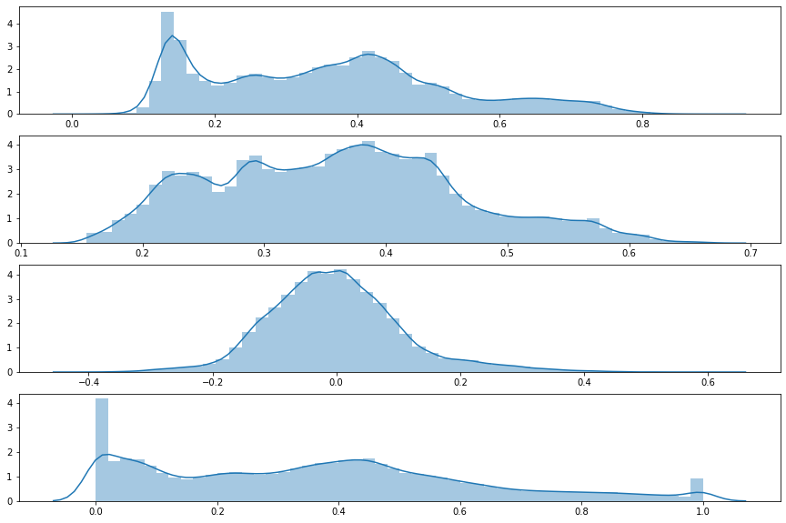

```python
f, axes = plt.subplots(4, 1, figsize = (15,10))
sns.distplot(lena.reshape((lena.shape[0]*lena.shape[1])), hist = True, ax = axes[0])
sns.distplot(gaus.reshape((lena.shape[0]*lena.shape[1])), hist = True, ax = axes[1])
sns.distplot(diff.reshape((lena.shape[0]*lena.shape[1])), hist = True, ax = axes[2])
sns.distplot(rec.reshape((lena.shape[0]*lena.shape[1])), hist = True, ax = axes[3])
```

Come si può vedere la diminuzione del parametro sigma ha cambiato di molto l'impatto sugli scuri dell'immagine; la distribuzione del valore dei pixel nell'immagine *enhanced* ottenuta con un **sigma** del filtro gaussiano pari a **20** è infatti molto più simile all'immagine originale rispetto a quella precedente ottenuta con un **sigma** pari a **50**.

A questo punto non resta che visualizzare i risultati di questo ulteriore tentativo a livello grafico.

[figure not shown]

```python
f, axes = plt.subplots(2,2, figsize = (15,15))
f.suptitle("Image enhancement")
axes[0][0].imshow(lena, cmap = 'gray')
axes[0][0].set_title('Original')
axes[0][1].imshow(gaus, cmap = 'gray')
axes[0][1].set_title("Gaus")
axes[1][0].imshow(diff, cmap = 'gray')
axes[1][0].set_title("Difference")
axes[1][1].imshow(rec, cmap = 'gray')
axes[1][1].set_title("Enhanced")
```

In ultimo, dopo aver provato valori molto elevati di **sigma** proviamo con un valore molto più contenuto, ovvero non superiore ma inferiore a quello di default:

```python
gaus = filters.gaussian(lena, sigma = 0.8, preserve_range = True)
diff = lena - gaus
rec = lena + diff
rec = np.where(rec < 0, 0, rec)
rec = np.where(rec > 1, 1, rec)
```

```python
print(lena.shape, np.max(lena), np.min(lena))
print(gaus.shape, np.max(gaus), np.min(gaus))
print(diff.shape, np.max(diff), np.min(diff))
print(rec.shape, np.max(rec), np.min(rec))
```

```
(400, 400) 0.8989145098039216 0.019776862745098038
(400, 400) 0.82691563565698 0.1104286364806964
(400, 400) 0.2927295738795337 -0.24042727096709668
(400, 400) 1.0 0.0
```

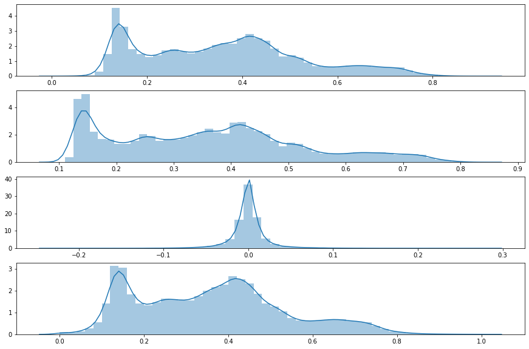

```python
f, axes = plt.subplots(4, 1, figsize = (15,10))
sns.distplot(lena.reshape((lena.shape[0]*lena.shape[1])), hist = True, ax = axes[0])
sns.distplot(gaus.reshape((lena.shape[0]*lena.shape[1])), hist = True, ax = axes[1])
sns.distplot(diff.reshape((lena.shape[0]*lena.shape[1])), hist = True, ax = axes[2])
sns.distplot(rec.reshape((lena.shape[0]*lena.shape[1])), hist = True, ax = axes[3])
```

[figure not shown]

```python
f, axes = plt.subplots(2,2, figsize = (15,15))
f.suptitle("Image enhancement")
axes[0][0].imshow(lena, cmap = 'gray')
axes[0][0].set_title('Original')
axes[0][1].imshow(gaus, cmap = 'gray')
axes[0][1].set_title("Gaus")
axes[1][0].imshow(diff, cmap = 'gray')
axes[1][0].set_title("Difference")
axes[1][1].imshow(rec, cmap = 'gray')
axes[1][1].set_title("Enhanced")
```

Appare evidente come utilizzando valori di **sigma** molto elevati si tenda quindi a snaturare l'immagine stravolgendo la distribuzione del valore dei pixel al suo interno mentre utilizzando valori più contenuti si contribuisca ad effettuare effettivamente un miglioramente dei dettagli come è possibile vedere sia dal plot della distribuzione dei pixel nella diverse fasi di questo ultimo esempio ma anche nell'immagine qui sopra riportata: la differenza infatti tra il prodotto del filtro gaussiano e l'immagine originale sono infatti i dettagli dell'immagine, sommando questi all'immagine originale, quindi, non si può far altro che metterli in ancora di più in risalto.